# R Project 2

## Summarizations

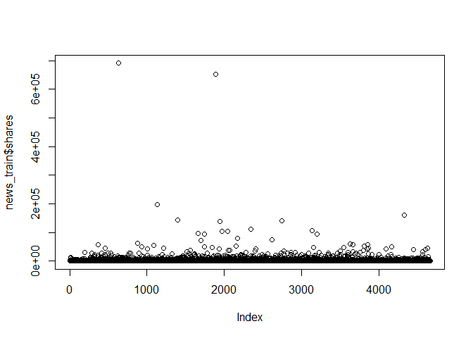

```r
# plot a visual of shares per article
plot(news_train$shares)
```

From the above plot, we can see any outliers. These could be affected by things beyond the variables we are observing in this model.

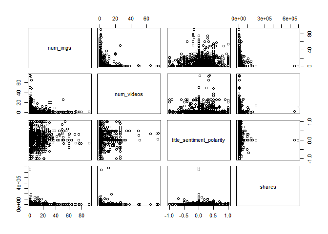

```r
# correlation plots of the variables selected
pairs(news_train[,2:5])
```

From the above plot, we can see any potential trends between the selected variables.

```r
# summary statistics of the variables selected
mean(news_train$shares)
```

```
## [1] 3674.113
```

```r
median(news_train$shares)
```

```
## [1] 1400
```

```r
sd(news_train$shares)
```

```
## [1] 16239.31
```

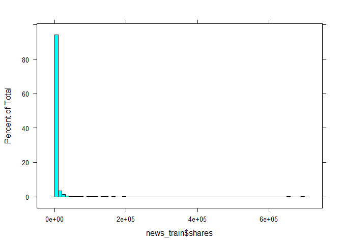

```r
histogram(news_train$shares, breaks=50)
```

A histogram displaying the spread of our response variable can be seen above.

## Modeling

```r
# create a non-ensemble tree model chosen using leave one out cross-validation
news_tree <- train(shares ~ .,
                   data=news_train,
                   method='rpart',
                   metric='MAE',
                   tuneLength=10,
                   trControl=trainControl(method='LOOCV'),
                   control=rpart.control(minsplit=1, minbucket=1)
                   )

# print out the results from our model selection
print(news_tree)
```

```
## CART
##
## 4664 samples
##    5 predictor
##
## No pre-processing
## Resampling: Leave-One-Out Cross-Validation
## Summary of sample sizes: 4663, 4663, 4663, 4663, 4663, 4663, ...
## Resampling results across tuning parameters:
##
##   cp            RMSE      Rsquared      MAE
##   0.0004326261  20400.00  3.630368e-06  4005.635
##   0.0005610314  20271.73  9.714746e-07  3932.673
##   0.0005778121  20259.81  5.011332e-07  3912.269
##   0.0006539318  20192.49  1.988386e-07  3877.384
##   0.0008204428  20123.03  3.760676e-07  3840.585
##   0.0010259957  20116.09  2.697044e-07  3839.310
##   0.0016764024  20077.39  9.952339e-08  3835.476
##   0.0019148960  20081.97  1.907504e-06  3842.241
##   0.0024109708  19853.49  1.493024e-06  3787.611
##   0.0179517994  18837.20  2.725892e-06  3700.914
##
## MAE was used to select the optimal model using the smallest value.
## The final value used for the model was cp = 0.0179518.
```

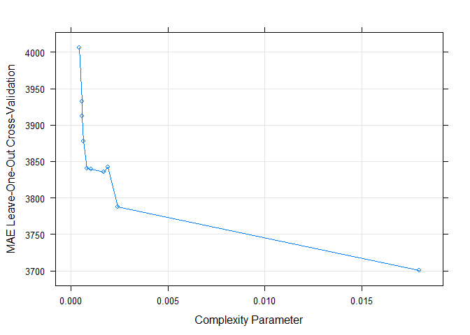

```r
# display a plot of the complexity values
plot(news_tree)
```

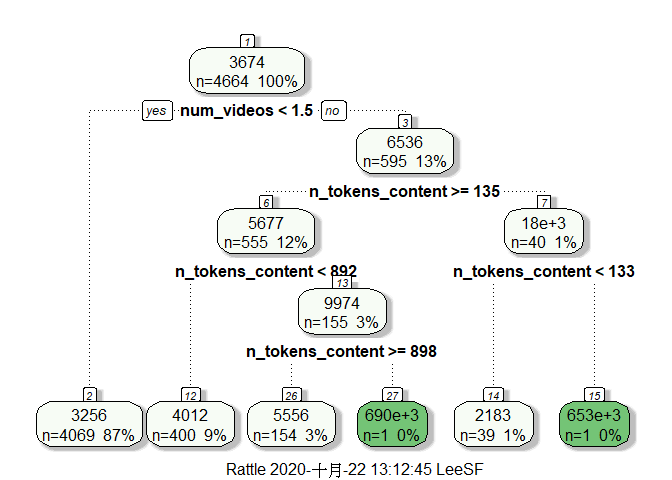

```r
# display a plot of the final tree model
fancyRpartPlot(news_tree$finalModel)
```

```r
# compare model to the test set
tree_pred <- predict(news_tree, newdata=news_test)
postResample(tree_pred, news_test$shares)
```

```
##         RMSE     Rsquared          MAE
## 1.780110e+04 2.620438e-05 3.801056e+03
```

Above we are fitting a tree-based model using leave one out cross validation. This is a regression tree, meaning we are trying to model a continuous response as opposed to classifying group membership. To fit this, for every possible value of each predictor, the MAE is found and minimized.

A potential issue with a tree-based method is that it can overfit our data, resulting in poorer performance when predicting on new data. This can be improved by pruning and cross-validation.

From the last output, we can see the mean absolute error (MAE). Because both models are using MAE as a means of optimization, we will compare this value to that received from boosting.

```r
# create a boosted tree model using cross-validation
boosted_tree <- train(shares ~ .,
                    data=news_train,
                    method='gbm',
                    metric='MAE',
                    tuneLength=10,
                    trControl=trainControl(method='repeatedcv', number=10, repeats=3)
                    )
```

```r
# print out the results from our model selection
print(boosted_tree)
```

```
## Stochastic Gradient Boosting
##
## 4664 samples
##    5 predictor
##
## No pre-processing
## Resampling: Cross-Validated (10 fold, repeated 3 times)
## Summary of sample sizes: 4198, 4197, 4197, 4199, 4199, 4197, ...
## Resampling results across tuning parameters:
##
##   interaction.depth  n.trees  RMSE      Rsquared     MAE
##    1                  50      12752.54  0.004612248  3737.035
##    1                 100      12776.33  0.004141044  3737.789
##    1                 150      12792.59  0.004049560  3737.046
##    1                 200      12806.23  0.003967205  3736.918
```

[output cut: 103 more lines]

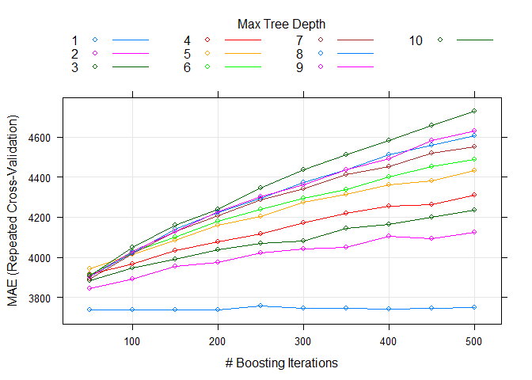

```r
# display a plot of the complexity values
plot(boosted_tree)
```

```r
# compare model to the test set
boosted_pred <- predict(boosted_tree, newdata=news_test)
postResample(boosted_pred, news_test$shares)
```

```
##         RMSE     Rsquared          MAE
## 1.020399e+04 5.498738e-03 3.684622e+03
```

A boosted tree model is an ensemble method, meaning it uses multiple learning algorithms to attempt to gain better performance than an individual model. The above model output and plot show the number of trees used in the final model and the tree depth.

This model performs better than the single tree-based model above in terms of out parameter of interest, MAE. This is likely due to a combination of the fact that the second model is using an ensemble method that fits more slowly, and the fact that singular tree-based models have a tendency to overfit their data, thus affecting the overall prediction value.

```r
# create a linear  model using repeated cross-validation
linear_regression <- train(shares ~ .,
                     data=news_train,
                     method='lm',
                     preProcess=c("center", "scale"),
                     metric='MAE',
                     tuneLength=10,
                     trControl=trainControl(method='repeatedcv', number=10, repeats=10)
                     )

linear_regression
```

```
## Linear Regression
##
## 4664 samples
##    5 predictor
##
## Pre-processing: centered (9), scaled (9)
## Resampling: Cross-Validated (10 fold, repeated 10 times)
## Summary of sample sizes: 4197, 4197, 4198, 4198, 4197, 4199, ...
## Resampling results:
##
##   RMSE      Rsquared     MAE
##   13039.94  0.004607571  3729.043
##
## Tuning parameter 'intercept' was held constant at a value of TRUE
```

```r
linear_pred <- predict(linear_regression, newdata=news_test)
postResample(linear_pred, news_test$shares)
```

```
##         RMSE     Rsquared          MAE
## 1.022925e+04 1.018668e-03 3.636107e+03
```